# 第七章 个人贷款

邱飞

万里学院

## 芝麻信用

- 截至2015年9月，人行征信中心的数据库中，只有8.5亿人的信息；这些信息可能十分有限，而且大多来自银行。这阻碍了个人贷款的发展。

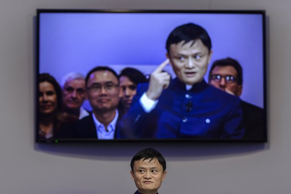

## 个人征信及意义

- 个人征信系统的建立是个人贷款大规模开展的前提。
- 个人征信评估必须依靠政府立法，组织、汇集多个部门的信息，全面、动态的反应个人信用状况。
- 有实力的银行也自己建立征信数据库。

## 个人贷款的特点

- 早期个人信贷主要是消费贷款， 目前个人经营和投资贷款的比重也在上升。
- 个人消费贷款对利率不敏感，主要取决于借款人的受教育程度、收入水平和社会地位。
- 个人贷款是商业银行提高竞争力的重要途径。

## 个人贷款的种类

1. 个人住房贷款
2. 个人汽车贷款
3. 个人综合消费贷款
4. 个人信用卡贷款
5. 个人经营投资贷款
6. 国家助学贷款

## 住房抵押贷款的风险

1. 信用风险
2. 利率风险
3. 提前偿付的风险
4. 抵押物风险

## 住房抵押贷款证券化

- 住房抵押贷款证券化指的是把缺乏流动性但具有未来现金流的住房抵押贷款汇集在一起，
- 通过结构重组和信用增级，
- 将其转变为可以在金融市场上出售和流动的证券(Mortgage-Backed Security,MBS)来融通资金的过程。

## MBS

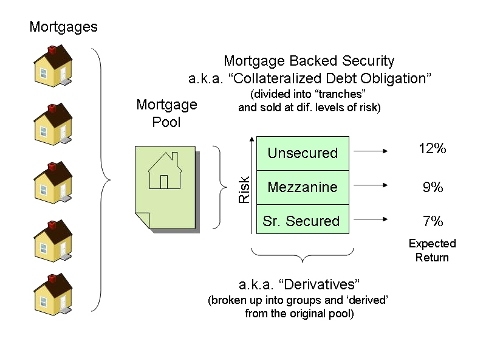

## 住房抵押贷款与次贷危机（subprime crisis）

- 美国的住房贷款分为“优惠级（prime）”和“次级（subprime）”两大类。
- 信用不好的借款人可以获得次级抵押贷款，利率比优惠级高2到3个百分点。
- 在房价上行周期，借款人赌房子继续涨价，而不在意过高的贷款利率，造成次级贷款大量发放。
- 房价下跌后，大量住房抵押贷款违约，造成了次贷危机。

## 美国次贷危机中的忍者(ninja)

> no income,no job and asset.
- 由于资产证券化(securitization)手段的存在，美国商业银行根本不考虑借款人的偿贷能力。
- 对于那些没有收入，没有工作和资产的人，也照样发放贷款。

## 个人综合消费贷款

- 在个人贷款中，除了住房贷款、个人经营贷款和信用卡透支外，各种用途的贷款都归属于综合消费贷款。
- 主要用于住房装修、购置耐用消费品（汽车、冰箱、彩电等）、教育支出、旅游和医疗等种类的消费。
- 由于居民消费习惯的原因国个人综合消费贷款规模不大，大约只占银行个人贷款总量中约占10%。

## 汽车贷款

1. 间客模式：银行通过汽车经销商提供贷款
2. 直客模式： 汽车购买者直接向银行申请贷款
3. 汽车金融公司贷款

## 为什么会出现汽车金融公司？

- 间客模式下，汽车经销商的信用风险和道德风险较高。
- 直客模式下，银行的管理和控制成本高，贷款规模难以满足需求。
- 汽车金融公司一般由汽车生产或销售厂家成立，他们既能控制风险，放款也比较灵活。

> 天下没有免费的午餐，汽车金融公司的贷款较银行汽车贷款利率高。

## 信用卡业务中外利润来源的不同

- 国外信用卡收入来自持卡人超期还款而支付的高利息。
- 国内信用卡收入主要来自信用卡特约商户的返点。

## 信用卡贷款的风险

1. 信用风险：信用卡属于无担保信用贷款
2. 伪卡风险：在芯片卡推出后，该项风险大大降低
3. 作业风险：信用卡非法套现

## 芯片卡与PBOC标准

- 芯片卡信息加密，避免被仿造。
- 芯片卡联机交易全程保持与终端的交互，避免了磁条卡一次交互易被伪冒交易的缺点。

## 个人经营贷款

- 个人经营贷款是指银行发放的、用于借款人合法经营活动所需资金周转的人民币贷款。
- 个人经营贷款的贷款对象虽然是自然人，但是它不属于个人消费贷款的范畴，其用途是以盈利为目的的经营活动的资金需求。

## 个人经营贷款特点

- 个人经营贷款的借款人必须是从事商业经营活动的主体，例如，个体工商户、独资或合伙中小企业的股东或主要出资人。
- 根据法律规定，个人经营贷款的借款人要对企业的债务负无限责任。

## fico得分在住房贷款中的应用

- fico分数范围：350-850，分值越高，信用度越好
- fico得分计算涉及45个指标
- 房贷发放考虑的两个核心指标：
1. payment-to-income(PTI)
2. loan-to-value(LTV)

## 房贷评价

- Fico得分超过660为prime等级
- prime要求PTI,front ratio < 28%,back ration < 36%
- prime要求LTV< 95%

## 房贷摊销表(Amortization)

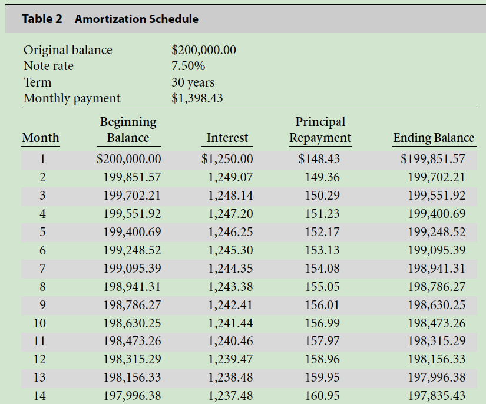

## 固定利率房贷t月后的本金计算公式

$$t月后的本金=贷款额\times\frac{(1+\frac{年利率}{12})^{12n}-(1+\frac{年利率}{12})^t}{(1+\frac{年利率}{12})^{12n}-1}$$

n表示贷款的年限

## 固定利率房贷第t月归还的本金计算公式

$$第t月归还的本金=贷款额\times\frac{(\frac{年利率}{12}) \times (1+\frac{年利率}{12})^{t-1}}{(1+\frac{年利率}{12})^{12n}-1}$$

n表示贷款的年限